# STAT 331 Portfolio

Author

Jasmine Cabrera

**My Grade:** I believe my grade equivalent to course work evidenced below to be an A.

**Learning Objective Evidence:** In the code chunks below, provide code from a Lab or Challenge assignment where you believe you have demonstrated proficiency with the specified learning target. Be sure to specify **where** the code came from (e.g., Lab 4 Question 2).

## Working with Data

**WD-1: I can import data from a *variety* of formats (e.g., csv, xlsx, txt, etc.).**

- `csv`

```r
# Lab 2 (Question 1)
surveys <- read_csv(here("surveys.csv"))
```

- `xlsx`

```r
# Practice Activity 4 (Question 1)
library(readxl)
military <- read_xlsx(here::here("data",
                                 "gov_spending_per_capita.xlsx"),
                      sheet = "Share of Govt. spending",
                      skip = 7,
                      n_max = 190)
```

- `txt`

```r
# Practice Activity 5.2 (Question 1)
message <- read_csv(here::here("scrambled_message.txt"))
```

**WD-2: I can select necessary columns from a dataset.**

```r
# Lab 3 (Question 5)
hiphop_clean <- hiphop |>
  select(
    word, subj, sex, age, ethnic, familiarity, trial,
    fam1, popularityScore, city, county, bieber) |>
  mutate(
    familarity = as.factor(familiarity))
```

**WD-3: I can filter rows from a dataframe for a *variety* of data types (e.g., numeric, integer, character, factor, date).**

- numeric

```r
# Lab 3 (Question 11)
hiphop_clean |>
  filter(age < 20,
         familiarity == 5) |>
  count(word, sort = TRUE)
```

- character – specifically a string

```r
# Practice Activity 5.2 (Question 4)
letterz <- message |>
      filter(str_ends(Word, "z"))
letterz
```

- factor

```r
# Lab 3 (Question 12)
hiphop_clean |>
  filter(ethnic != "white",
         sex == "Female",
         familiarity == 5) |>
  count(word, sort = TRUE)
```

- date

```r
# Practicy Activity 5.1 (Question 4)
Iceland <- with_tz(suspects$Time.Spotted, tzone = "Iceland")
suspects <- suspects |>
  filter(pm(Iceland) == TRUE,
         day(Time.Spotted) %in% c(22, 23, 24))
```

**WD-4: I can modify existing variables and create new variables in a dataframe for a *variety* of data types (e.g., numeric, integer, character, factor, date).**

- numeric

```r
# Challenge 3 (Question 1)
hiphop_male <- hiphop |>
  distinct(subj, .keep_all = TRUE) |>
  group_by(sex) |>
  summarize(across(.cols = intl:unclassifiable,
                   .fns = ~ mean(.x, na.rm = TRUE))) |>
  pivot_longer("intl":"unclassifiable",
               names_to = "Genres",
               values_to = "Mean") |>
  pivot_wider(names_from = "sex",
              values_from = "Mean") |>
  mutate(Difference = Female - Male) |>
  print()
```

- character – specifically a string

```r
# Practice Activity 5.2 (Question 5)
punc <- message |>
      filter(str_detect(Word, pattern = "[:punct:]")) |>
      mutate(Word = str_extract(Word, pattern = "[:punct:]"))
punc
```

- factor

```r
# Lab 3 (Question 7)
hiphop_clean <- hiphop_clean |>
  mutate(ethnic_bin =
           case_when(ethnic == "white" ~ "white",
                           TRUE ~ "non-white"))
```

- date

```r
# Practice Activity 5.1 (Question 6)
suspects <- suspects |>
  mutate(time = difftime(Time.Spotted, init, units = "mins"),
         time = as.integer(time)) |>
  filter(time %% 10 == 0)
```

**WD-5: I can use mutating joins to combine multiple dataframes.**

- `left_join()`

```r
# n/a :(
```

- `right_join()`

```r
# n/a :(
```

- `inner_join()`

```r
# Preview Activity 4
inner_join(prof_info, prof_course)
```

- `full_join()`

```r
# Lab 7 (Part 3.6)
rescale_col_test <- blackfoot |>
  rescale_column(length:weight) |>
  mutate(id = seq_along(1:nrow(blackfoot))) |>
  select(id, length:weight)


rescale_confirm <- blackfoot |>
  mutate(across(.cols = length:weight,
                .fns = ~ rescale(.x,
                                 to = c(0,1),
                                 from = range(.x,
                                              na.rm = TRUE,
                                              finite = TRUE)))) |>
  mutate(id = seq_along(1:nrow(blackfoot))) |>
  select(id, length:weight) |>
  rename("rescale(length)" = "length",
         "rescale(weight)" = "weight")


rescale_compare <- full_join(rescale_col_test,
                             rescale_confirm,
                             by = "id")
rescale_compare <- rescale_compare |>
  select("weight", "rescale(weight)",
         "length", "rescale(length)")
rescale_compare
```

**WD-6: I can use filtering joins to filter rows from a dataframe.**

- `semi_join()`

```r
# Lab 9 (Part 5 Question 8 (revised))
allans <- tibble(Name = c("Allan",
                          "Alan",
                          "Allen"))

allan_names <- names |>
  filter(Gender == "M") |>
  semi_join(allans, by = "Name") |>
  rename(Sex = Gender) |>
  print()
```

- `anti_join()`

```r
# Practice Activity 4
military_clean <- military_clean |>
  anti_join(cont_region,
            by = c("Country" = "Region"))
```

**WD-7: I can pivot dataframes from long to wide and visa versa**

- `pivot_longer()`

```r
# Lab 7 (Part 2.1)
NAsum <- blackfoot |>
  mutate(across(.cols = trip : species,
                .fns = ~ sum(is.na(.x)))) |>
  pivot_longer("trip" : "species",
               names_to = "Variable Name",
               values_to = "Missing Values")
head(NAsum)
```

- `pivot_wider()`

```r
# Challenge 3 (Question 1)
hiphop_male <- hiphop |>
  distinct(subj, .keep_all = TRUE) |>
  group_by(sex) |>
  summarize(across(.cols = intl:unclassifiable,
                   .fns = ~ mean(.x, na.rm = TRUE))) |>
  pivot_longer("intl":"unclassifiable",
               names_to = "Genres",
               values_to = "Mean") |>
  pivot_wider(names_from = "sex",
              values_from = "Mean") |>
  mutate(Difference = Female - Male) |>
  print()
```

## Reproducibility

**R-1: I can create professional looking, reproducible analyses using RStudio projects, Quarto documents, and the here package.**

**R-2: I can write well documented and tidy code.**

- Example 1

```r
# Lab 2 (Question 11)
ggplot(data = surveys,
       mapping = aes(x = weight,
                    y = species)) +
  geom_jitter(color = "tomato") +
  geom_boxplot() +
  labs(title = "Distribution of Weight Within Each Species",
       x = "Weight (g)",
       y = "Species")
```

- Example 2

```r
# Chalenge 3 (Question 2)
hiphop_white <- hiphop |>
  distinct(subj, .keep_all = TRUE) |>
  mutate(ethnic_bin =
         case_when(ethnic == "white" ~ "White",
                   TRUE ~ "NotWhite")) |>
  group_by(ethnic_bin) |>
  summarize(across(.cols = intl:unclassifiable,
                   .fns = ~ mean(.x, na.rm = TRUE))) |>
  pivot_longer("intl":"unclassifiable",
               names_to = "Genres",
               values_to = "Mean") |>
  pivot_wider(names_from = "ethnic_bin",
              values_from = "Mean") |>
  mutate(Difference = NotWhite - White) |>
  print()
```

**R-3: I can write robust programs that are resistant to changes in inputs.**

- Example 1

```r
# Lab 3 (Question 14)
findbieber <- hiphop_clean |>
  distinct(subj, .keep_all = TRUE)

findbieber |>
  filter(sex == "Male",
         between(age, 17, 23),
         ethnic == "white",
         between(city, 10000, 60000)) |>
  slice_max(bieber)
```

- Example 2

```r
# Lab 7 (Part 3.5)
rescale_column <- function(dataframe, variables){
  stopifnot(is.data.frame(dataframe))

  dataframe <- dataframe |>
    mutate(across(.cols = {{variables}},
                  ~ rescale_01(.x)))

  return(dataframe)
}
```

## Data Visualization & Summarization

**DVS-1: I can create visualizations for a *variety* of variable types (e.g., numeric, character, factor, date)**

- numeric variables

```r
# Lab 2 (Question 7)
ggplot(data = surveys) +
  geom_jitter(mapping = aes(x = weight,
                            y = ftlength),
             alpha = 0.3,
             width = 1,
             height = 1) +
  facet_wrap(~ species) +
  labs(title = "Relationship Between Weight and Hindfoot Length",
       x = "Weight (g)",
       y = "Hindfoot Length (mm)")
```

- numeric variables and categorical variables

```r
# Lab 2 (Question 8)
ggplot(data = surveys) +
  geom_boxplot(mapping = aes(x = weight,
                             y = species)) +
  labs(title = "Distribution of Weight Within Each Species",
       x = "Weight (g)",
       y = "Species")
```

- categorical variables

```r
# Lab 3 (Question 10)
ggplot(data = new_hiphop,
       mapping = aes(x = sex,
                     fill = ethnic)) +
  geom_bar() +
  labs(title = "Distribution of Ethnicity by Sex",
       x = "Sex",
       y = "Number of Participants")
```

- dates

```r
# Lab 5 (Question 4)
surveys |>
  group_by(year, genus) |>
  summarize(
    avg_weight = mean(weight, na.rm = TRUE)) |>
  ggplot(mapping = aes(x = year,
                       y = avg_weight,
                       colour = fct_reorder2(genus,
                                             year,
                                             avg_weight))) +
        geom_line() +
        labs(x = "Year",
             y = NULL,
             title = "Average Weight (g)",
             colour = "Genus")
```

**DVS-2: I use plot modifications to make my visualization clear to the reader.**

- Example 1

```r
# Lab 5 (Question 4)
surveys |>
  group_by(year, genus) |>
  summarize(
    avg_weight = mean(weight, na.rm = TRUE)) |>
  ggplot(mapping = aes(x = year,
                       y = avg_weight,
                       colour = fct_reorder2(genus,
                                             year,
                                             avg_weight))) +
        geom_line() +
        labs(x = "Year",
             y = NULL,
             title = "Average Weight (g)",
             colour = "Genus")
```

- Example 2

```r
# Lab 2 (Question 6)
ggplot(data = surveys) +
  geom_jitter(mapping = aes(x = weight,
                            y = ftlength),
             alpha = 0.3,
             width = 1,
             height = 1) +
  labs(title = "Relationship Between Weight and Hindfoot Length",
       x = "Weight (g)",
       y = "Hindfoot Length (mm)")
```

**DVS-3: I show creativity in my visualizations**

- Example 1

```r
# Lab 7 (Part 2.2)
visualizing <- blackfoot |>
  filter(if_any(.cols = trip : species,
                .fns = ~ is.na(.x))) |>
  mutate(trip = as.factor(trip),
         year = as.factor(year)) |>
  rename("Trip" = trip)

ggplot(data = visualizing,
       mapping = aes(x = year,
                     fill = section)) +
  geom_bar() +
  facet_wrap(~ Trip,
             labeller = labeller(Trip = label_both)) +
        labs(x = "Year",
             y = NULL,
             title = "Observations with Missing Values",
             fill = "Section") +
  scale_x_discrete(guide = guide_axis(n.dodge = 2)) +
  scale_fill_manual(values = c("#73E289",
                               "#768CE5"))
```

- Example 2

```r
# Challenge 2 (Ugly Plot Challenge)
ggplot(data = penguins) +
  geom_point(mapping = aes(x = bill_length_mm,
                           y = bill_depth_mm,
                           color = flipper_length_mm,
                           shape = island,
                           size = body_mass_g)) +
  labs(title =
         "Relationship Between Penguins in Palmer
          Penguins Data Set",
       x = "Bill Length (mm)",
       y = "Bill Depth (mm)",
       color = "Flipper Length",
       shape = "Island",
       size = "Body Mass (g)") +
  xlim(0, 200) +
  ylim(0, 40)
```

**DVS-4: I can calculate numerical summaries of variables.**

- Example 1

```r
# Challenge 3 (Question 1)
hiphop_male <- hiphop |>
  distinct(subj, .keep_all = TRUE) |>
  group_by(sex) |>
  summarize(across(.cols = intl:unclassifiable,
                   .fns = ~ mean(.x, na.rm = TRUE))) |>
  pivot_longer("intl":"unclassifiable",
               names_to = "Genres",
               values_to = "Mean") |>
  pivot_wider(names_from = "sex",
              values_from = "Mean") |>
  mutate(Difference = Female - Male) |>
  print()
```

- Example 2

```r
# Lab 7 (Part 2.1)
NAsum <- blackfoot |>
  mutate(across(.cols = trip : species,
                .fns = ~ sum(is.na(.x)))) |>
  pivot_longer("trip" : "species",
               names_to = "Variable Name",
               values_to = "Missing Values")
head(NAsum)
```

**DVS-5: I can find summaries of variables across multiple groups.**

- Example 1

```r
# Lab 9 (Part 3 Question 3)
allison_f <- names |>
  rename(Sex = Gender) |>
  filter(Name == "Allison") |>
  group_by(Year) |>
  summarize(Total = sum(Count)) |>
  ggplot(mapping = aes(x = Year,
                       y = Total)) +
  geom_line() +
  labs(y = NULL,
       title = "Total Number of Allisons Born Between 1997-2014") +
  scale_x_continuous(breaks = seq(1997, 2014, by = 1),
                     guide =  guide_axis(n.dodge = 2)) +
  scale_y_continuous(breaks = seq(5000, 9000, by = 1000),
                     limits = c(5000, 8000)) +
  theme(plot.title = element_text(face = "bold",
                                  hjust = 0.5))
allison_f
```

- Example 2

```r
# Lab 9 (Part 5 Question 9 (revised))
allan <- allan_names |>
  pivot_wider(names_from = "Name",
              values_from = "Count",
              values_fill = 0) |>
  filter(Year == 2000) |>
  mutate(Total = Allan + Allen + Alan,
         across(.cols = Allen:Allan,
                .fns = ~ .x/Total,
                .names = "{col}Prop"),
         OverallProp = Total/sum(Total)) |>
  select(Year, Sex, State, Allen, AllenProp, Alan, AlanProp, Allan,
         AllanProp, Total, OverallProp) |>
  print()
```

**DVS-6: I can create tables which make my summaries clear to the reader.**

- Example 1

```r
# Challenge 9 (Part 3 Question 1)
allison |>
  knitr::kable(format = "html",
               col.names = c("State",
                             "Female",
                             "Male"),
               caption = "Frequency of Allisons in Each State") |>
  kableExtra::kable_classic(html_font = "Arial") |>
  kableExtra::kable_styling(bootstrap_options = "striped")
```

- Example 2

```r
# Challenge 9 (Part 5)
allan |>
  knitr::kable(format = "html",
               col.names = c("Year",
                             "Sex",
                             "State",
                             "Allen",
                             "Allen Proportion in State",
                             "Alan",
                             "Alan Proportion in State",
                             "Allan",
                             "Allan Proportion in State",
                             "Total",
                             "Overall State Proportion in Year"),
               caption = "Summary of Frequency and Proportion of
                         'Allen', 'Allan, and 'Allan' in Each
                         State") |>
  kableExtra::kable_classic(html_font = "Arial") |>
  kableExtra::kable_styling(bootstrap_options = "striped")
```

**DVS-7: I show creativity in my tables.**

- Example 1

```r
# Challenge 9 (Part 5 Question 10)
allan_ca_pa |>
  knitr::kable(format = "html",
               col.names = c("Year",
                             "Sex",
                             "State",
                             "Allen",
                             "Allen Proportion in State",
                             "Alan",
                             "Alan Proportion in State",
                             "Allan",
                             "Allan Proportion in State",
                             "Total",
                             "Overall State Proportion in Year"),
               caption = "Summary of Frequency and Proportion of
                         'Allen', 'Allan, and 'Allan' in California
                         and Pennsylvania",
               digits = 3) |>
  kableExtra::kable_classic(html_font = "Cambria") |>
  kableExtra::kable_styling(bootstrap_options = "striped",
                            position = "left")
```

- Example 2

```r
# Challenge 9 (Part 3 Question 1 (revised))
 allison |>
  knitr::kable(format = "html",
               col.names = c("State",
                             "Female",
                             "Male"),
               caption = "Frequency of Allisons in Each State") |>
  kableExtra::kable_classic_2(html_font = "Cambria") |>
  kableExtra::kable_styling(bootstrap_options = "striped",
                            position = "left",
                            font_size = 15)
```

## Program Efficiency

**PE-1: I can write concise code which does not repeat itself.**

- using a single function call

```r
# Lab 3 (Question 14)
findbieber |>
  filter(sex == "Male",
         between(age, 17, 23),
         ethnic == "white",
         between(city, 10000, 60000)) |>
  slice_max(bieber)
```

- `across()`

```r
# Lab 9 (Part 5 Question 10)
allan <- allan_names |>
  pivot_wider(names_from = "Name",
              values_from = "Count",
              values_fill = 0) |>
  filter(Year == 2000) |>
  mutate(Total = Allan + Allen + Alan,
         across(.cols = Allen:Allan,
                .fns = ~ .x/Total,
                .names = "{col}Prop"),
         OverallProp = Total/sum(Total)) |>
  select(Year, Sex, State, Allen, AllenProp, Alan, AlanProp, Allan,
         AllanProp, Total, OverallProp) |>
  print()
```

- `map()` functions

```r
# Lab 8 (Question 1)
xmas2 <- xmas |>
  mutate(Full.Phrase = pmap_chr(.l = list(day = Day,
                                          num_word = Day.in.Words,
                                          item = Gift.Item,
                                          verb = Verb,
                                          adjective = Adjective,
                                          location = Location),
                                .f = make_phrase))
```

**PE-2: I can write functions to reduce repetition in my code.**

- Example 1

```r
# Lab 7 (Part 3.1)
rescale_01 <- function(vec){

  stopifnot(is.numeric(vec), length(vec) > 1)

  max = max(vec, na.rm = TRUE)
  min = min(vec, na.rm = TRUE)

  return ((vec - min) / (max - min))
}
```

- Example 2

```r
# Lab 7 (Part 3.5 (revised))
rescale_column <- function(dataframe, variables){
  stopifnot(is.data.frame(dataframe))

  dataframe <- dataframe |>
    mutate(across(.cols = {{variables}},
                  .fns = ~ rescale_01(.x)))

  return(dataframe)
}
```

**PE-3: I can use iteration to reduce repetition in my code.**

- `across()`

```r
# Lab 9 (Part 5 Question 9 (revised))
allan <- allan_names |>
  pivot_wider(names_from = "Name",
              values_from = "Count",
              values_fill = 0) |>
  filter(Year == 2000) |>
  mutate(Total = Allan + Allen + Alan,
         across(.cols = Allen:Allan,
                .fns = ~ .x/Total,
                .names = "{col}Prop"),
         OverallProp = Total/sum(Total)) |>
  select(Year, Sex, State, Allen, AllenProp, Alan, AlanProp, Allan,
         AllanProp, Total, OverallProp) |>
  print()
```

- `map()` functions (Provide 2 Examples)

```r
# Lab 8 (Question 1)
xmas2 <- xmas |>
  mutate(Full.Phrase = pmap_chr(.l = list(day = Day,
                                          num_word = Day.in.Words,
                                          item = Gift.Item,
                                          verb = Verb,
                                          adjective = Adjective,
                                          location = Location),
                                .f = make_phrase))
```

```r
# Lab 8 (Part 4)
song_create <- function(n){
song <- map_chr(.x = 1:n,
                .f = ~ sing_line(dataset = xmas2,
                                 line = .x,
                                 phrase_col = Full.Phrase)) |>
  str_c(collapse = "\n\n")
return(glue::glue("{song}"))}
song_create(12)
```

**PE-4: I can use modern tools when carrying out my analysis.**

- Example 1

```r
# Lab 7 (Part 2.2)
visualizing <- blackfoot |>
  filter(if_any(.cols = trip : species,
                .fns = ~ is.na(.x))) |>
  mutate(trip = as.factor(trip),
         year = as.factor(year)) |>
  rename("Trip" = trip)
```

- Example 2

```r
# Lab 3 (Question 14)
findbieber <- hiphop_clean |>
  distinct(subj, .keep_all = TRUE)

findbieber |>
  filter(sex == "Male",
         between(age, 17, 23),
         ethnic == "white",
         between(city, 10000, 60000)) |>
  slice_max(bieber)
```

## Data Simulation & Modeling

**DSM-1: I can simulate data from a *variety* of probability models.**

- Example 1

```r
# Practice Activity 9.2 (Part 2)
1 - punif(5, 1.5, 3.5, lower.tail = TRUE)
```

- Example 2

```r
# Practice Activity 9.2 (Part 2)
trom <- rnorm(100, 4.6, 0.8)
sum(trom < 4)
```

**DSM-2: I can fit a linear regression and extract necessary summary measures.**

- Example 1

```r
# Practice Activity 9.1
animal_lm <- animal |>
  lm(weight_after ~ weight_before, data = _) |>
  print()

animal_lm |>
  broom::augment() |>
  ggplot(mapping = aes(y = .resid,
                       x = .fitted)) +
  geom_point()
```

- Example 2

```r
# Lab 9 (Part 4 Question 4)
allison_lm <- allison_f |>
  group_by(Year) |>
  summarize(Total = sum(Count)) |>
  lm(Total ~ Year, data = _) |>
  print()

allison_lm |>
  broom::augment() |>
  ggplot(mapping = aes(y = .resid,
                       x = .fitted)) +
  geom_point() +
  labs(x = "Fitted",
       y = NULL,
       title = "Residual Plot") +
  scale_x_continuous(breaks = seq(5000, 7000, by = 500),
                     limits = c(5000, 7000)) +
  scale_y_continuous(breaks = seq(-1000, 1000, by = 500),
                     limits = c(-1250, 1250)) +
  theme(plot.title = element_text(face = "bold",
                                  hjust = 0.5))
```

## Revising My Thinking

Prior to the first reflection, I had received “Growing” in several labs and challenges I needed improvement on and other suggestions on how to make my code more robust. From the very beginning, in Lab 1, Dr. Theobold stated “it is more resistant to extract a variable based on its name rather than its position in the dataset (2nd column)”. Since then, I have modified my code to reflect this and called variables using the “$” sign. Another example would be in Lab 3. In this assignment, I received several “Growing” many of which had to do with the format of the Quarto document, but one was hinting at a better way to “write code to find the maximum of that variable and the subject associated with it.” Instead of filtering the variable for a certain number, in my revision, I used the slice_max() function. Overall, the comments left by Dr. Theobold, helped me realize that there are several ways to approach code, however, some are arguably better than others.

Following the first reflection, my revisions have not stopped. One of my favorites was for Lab 9 Part 5 Question 9. Initially, I had several mutate functions that performed the same calculation on different columns, but each would result in a different name. After I received feedback from Dr. Theobold, I learned that the across function paired with the mutate function would be more efficient. From there, I was able to look closer at the across function and its “options” one of which being “.names”. I combined the knowledge from the weeks prior such as the use of “{}” for variable names with what I learned about the across function to minimize and tidy my code. Overall, I am still continuing to learn, but the knowledge I obtained from the weeks prior continues to stack on top of each other and help me be a better coder.

## Extending My Thinking

**Prior to First Reflection:**

When I had extra free time, I tried to expand my knowledge and improve my code through other educational websites. In Lab 2, Question 3 asked what the data types of each variable was in the data set. Though most of the variables were listed as character or numeric, one was listed as a Date variable. I wasn’t sure if “Date” was a variable type of its own or something else. After further research, I discovered that Dates were stored as numerical values in R and thus answered the question as such. Another example was in Lab 3, Question 14. The purpose of Question 14 was to filter data to find Justin Bieber. From previous revisions, I recognized that there are more efficient ways to write code so I looked up a better way to write double sided inequalities rather than doing a filter twice for the same variable. One website introduced me to the between() function which works similarly to double sided inequalities. I used this function in my code and overall it was more efficient and I no longer had to write repettetive code for filtering numeric values.

**After First Reflection:**

I have continued to extend my thinking as the weeks progressed in this course. In Lab 7, I explored more options in the tidyverse, more specifically the if_any function and the facet_wrap option “labeller”. One of the first problems I encountered was that some of the tidyverse functions were being deprecated. In order to achieve the output I wanted, I had to look into the if_any function which served as a replacement for the across function when filtering the data set. Regarding the labeller option, I was experimenting with ggplot to come up with a creative graph. One of the functions I used was facet_wrap which allowed me to have two plots side by side (each one being a different Trip). However, when the plots were created, they were labelled as “1” and “2” for the Trip Number. This is where the labeller option came into play as I was able to change the labels to “Trip: 1” and “Trip: 2” which took my graphs to the next level by making it easier for the reader to understand them.

## Peer Support & Collaboration

**Prior to First Reflection:**

[figure not shown]

Discord - Lab 2 Assignment Channel

[figure not shown]

Discord - Lab 3 Assignment Channel

**After First Reflection:**

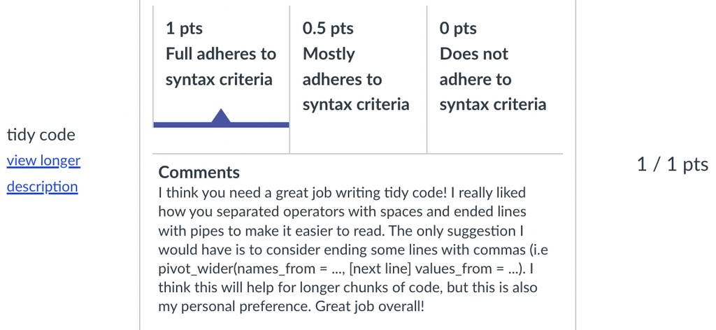

Peer Review - Lab 9 (Part 1)

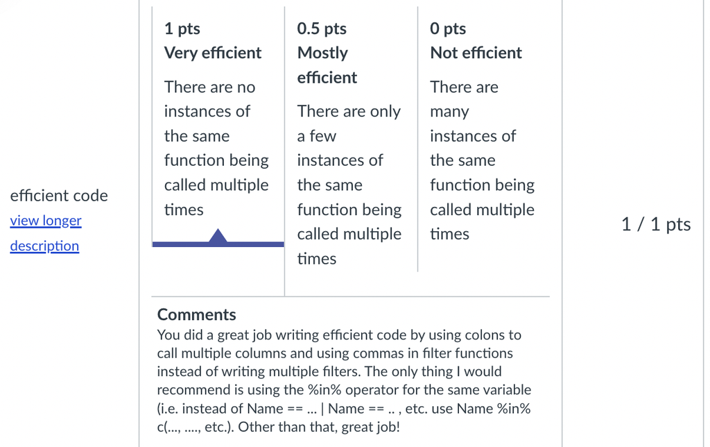

Peer Review - Lab 9 (Part 2)